# **Panorama da inflação**

Os principais índices de inflação do Brasil, apontam em setembro de 2020 um avanço da inflação de em média **1.95%**. Com esse resultado, no ano a inflação acumula uma variação média positiva de **5.75%**, e em 12 meses uma variação média acumulada de **8.32%**.

[output not shown]

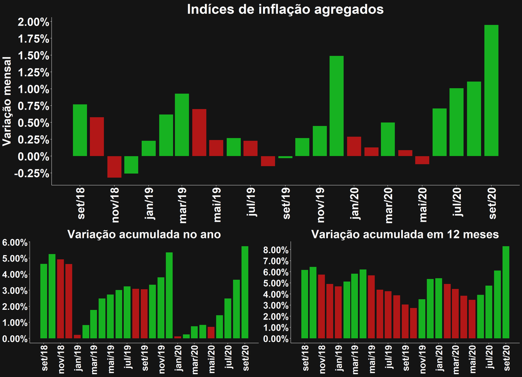

Índices selecionados para a média: IPCA, INPC e IGP-M.

# IPCA

O Indíce de Preços ao Consumidor Amplo (IPCA) variou 0.64% em setembro, valor superior ao mesmo período do ano anterior quando apresentou uma taxa de -0.04%. Com esse resultado o indíce acumula no ano uma variação positiva de 1.34%, e em 12 meses uma variação positiva de 3.14%.

|  | 09/2019 | 08/2020 | 09/2020 |
| --- | --- | --- | --- |
| Variação mensal | -0.04% | 0.24% | 0.64% |
| Variação acumulada no ano | 2.49% | 0.7% | 1.34% |
| Variação acumulada em 12 meses | 2.89% | 2.44% | 3.14% |

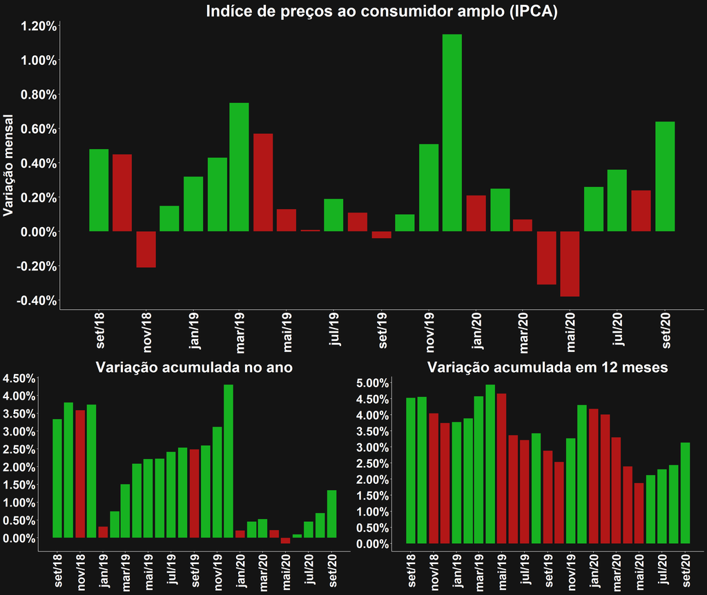

Os grupos que tiveram maior resultado positivo foram Alimentação e bebidas (2.28%) e Artigos de residência (1%), e negativo Saúde e cuidados pessoais (-0.64%) e Educação (-0.09%).

|  | Variação mensal | Variação acumulada no ano | Peso mensal |
| --- | --- | --- | --- |
| Alimentação e bebidas | 2.28% | 7.31% | 20.16% |
| Habitação | 0.37% | 1.51% | 15.66% |
| Artigos de residência | 1% | 1.72% | 3.75% |
| Vestuário | 0.37% | -2.84% | 4.4% |
| Transportes | 0.7% | -2.79% | 19.75% |
| Saúde e cuidados pessoais | -0.64% | 0.95% | 13.65% |
| Despesas pessoais | 0.09% | 0.17% | 10.67% |
| Educação | -0.09% | 0.71% | 6.15% |
| Comunicação | 0.15% | 2.51% | 5.81% |

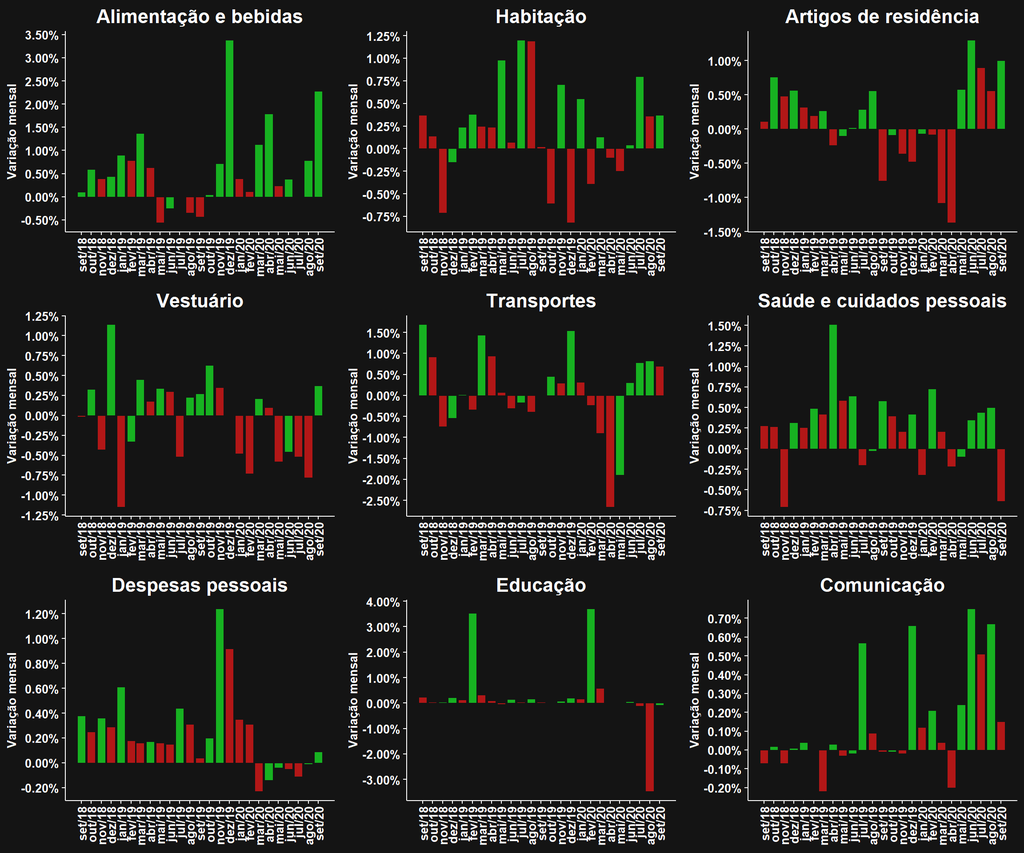

A nível de sub-itens os que mais influenciaram positivamente no resultado em relação ao seu peso foram Arroz (17.98%%) e Gasolina (1.95%%), e negativamente Plano de saúde (-2.31%%) e Seguro voluntário de veículo (-2.73%%).

|  | Variação mensal | Variação acumulada no ano | Peso mensal |
| --- | --- | --- | --- |
| Leite longa vida | 6.01% | 30.39% | 0.75% |
| Óleo de soja | 27.54% | 51.29% | 0.21% |
| Arroz | 17.98% | 40.67% | 0.56% |
| Gasolina | 1.95% | -4.08% | 4.81% |

|  | Variação mensal | Variação acumulada no ano | Peso mensal |
| --- | --- | --- | --- |
| Cebola | -11.8% | 32.64% | 0.15% |
| Mamão | -15.12% | 7.67% | 0.09% |
| Plano de saúde | -2.31% | 2.47% | 4.19% |
| Seguro voluntário de veículo | -2.73% | -11.86% | 0.75% |

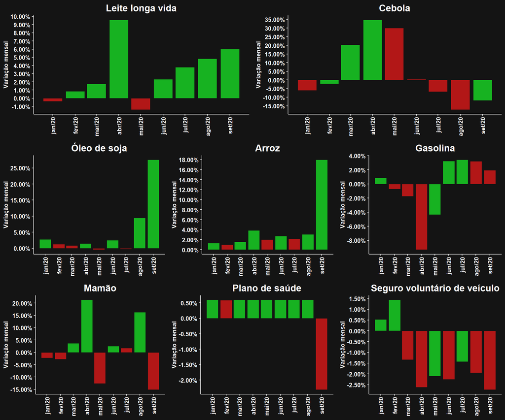

# INPC

O Indíce Nacional de Preços ao Consumidor (INPC) variou 0.87% em setembro, valor superior ao mesmo período do ano anterior quando apresentou uma taxa de -0.05%. Com esse resultado o indíce acumula no ano uma variação positiva de 2.04%, e em 12 meses uma variação positiva de 3.89%.

|  | 09/2019 | 08/2020 | 09/2020 |
| --- | --- | --- | --- |
| Variação mensal | -0.05% | 0.36% | 0.87% |
| Variação acumulada no ano | 2.63% | 1.16% | 2.04% |
| Variação acumulada em 12 meses | 2.92% | 2.94% | 3.89% |

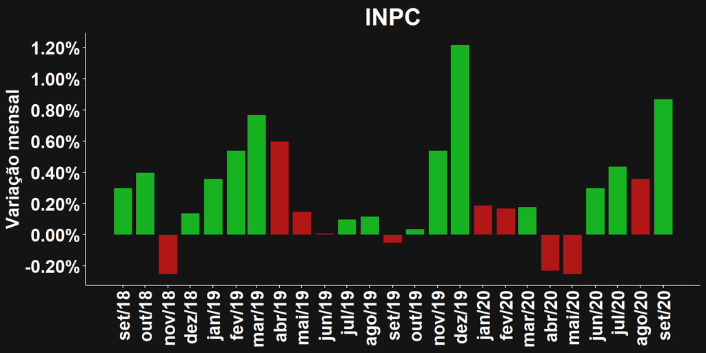

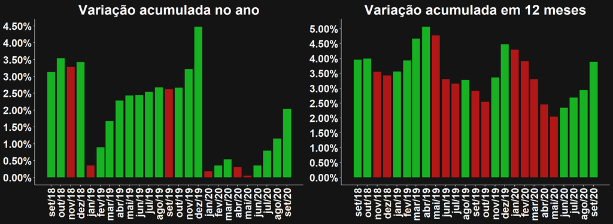

# IGP-M

O Indíce Geral de Preços de Mercado (IGP-M) variou 4.34% em setembro, valor superior ao mesmo período do ano anterior quando apresentou uma taxa de -0.01%. Com esse resultado o indíce acumula no ano uma variação positiva de 13.86%, e em 12 meses uma variação positiva de 17.94%.

|  | 09/2019 | 08/2020 | 09/2020 |
| --- | --- | --- | --- |
| Variação mensal | -0.01% | 2.74% | 4.34% |
| Variação acumulada no ano | 4.08% | 9.12% | 13.86% |
| Variação acumulada em 12 meses | 3.37% | 13.02% | 17.94% |

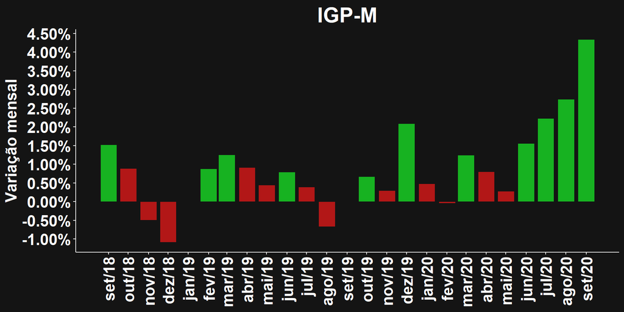

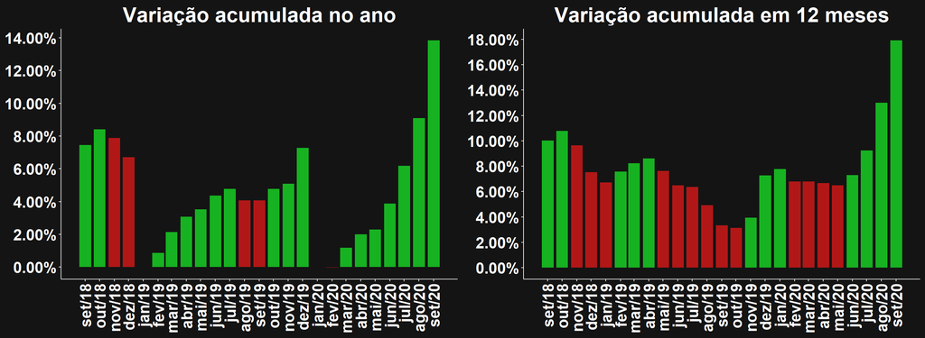

# IGP-DI

O Indíce Geral de Preços - Disponibilidade Interna (IGP-DI) variou 3.3% em setembro, valor superior ao mesmo período do ano anterior quando apresentou uma taxa de 0.5%. Com esse resultado o indíce acumula no ano uma variação positiva de 14.69%, e em 12 meses uma variação positiva de 18.44%.

|  | 09/2019 | 08/2020 | 09/2020 |
| --- | --- | --- | --- |
| Variação mensal | 0.5% | 3.87% | 3.3% |
| Variação acumulada no ano | 4.32% | 11.03% | 14.69% |
| Variação acumulada em 12 meses | 3% | 15.23% | 18.44% |

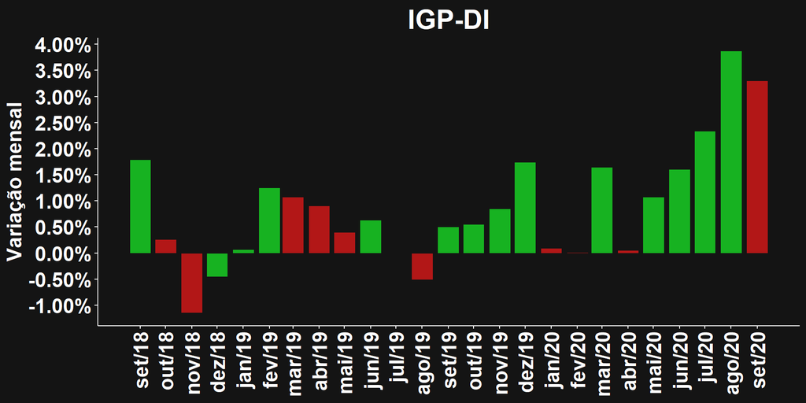

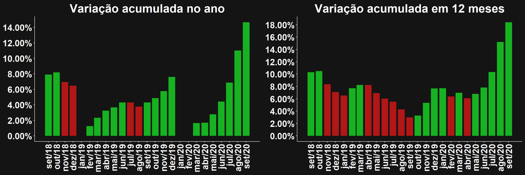

[output not shown]

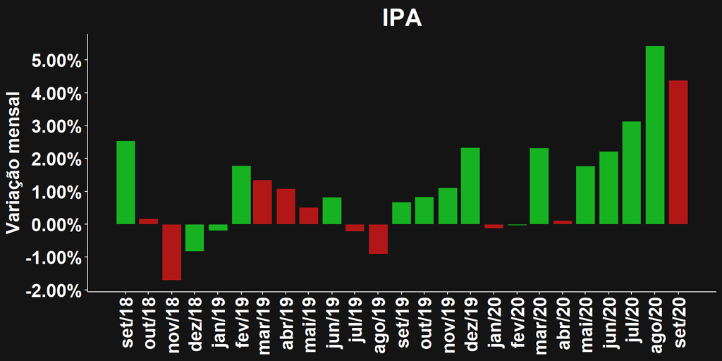

[figure not shown]

O Indíce de Preços ao Consumidor (IPC), integrante do IGP-DI com peso de 30%, apresentou variação de 0.82% em setembro, valor superior ao mesmo período do ano anterior quando apresentou uma taxa de 0%. Com esse resultado o indíce acumula no ano uma variação positiva de 1.82%, e em 12 meses uma variação positiva de 3.62%.

|  | 09/2019 | 08/2020 | 09/2020 |
| --- | --- | --- | --- |
| Variação mensal | 0% | 0.53% | 0.82% |
| Variação acumulada no ano | 2.32% | 0.99% | 1.82% |
| Variação acumulada em 12 meses | 3.51% | 2.77% | 3.62% |

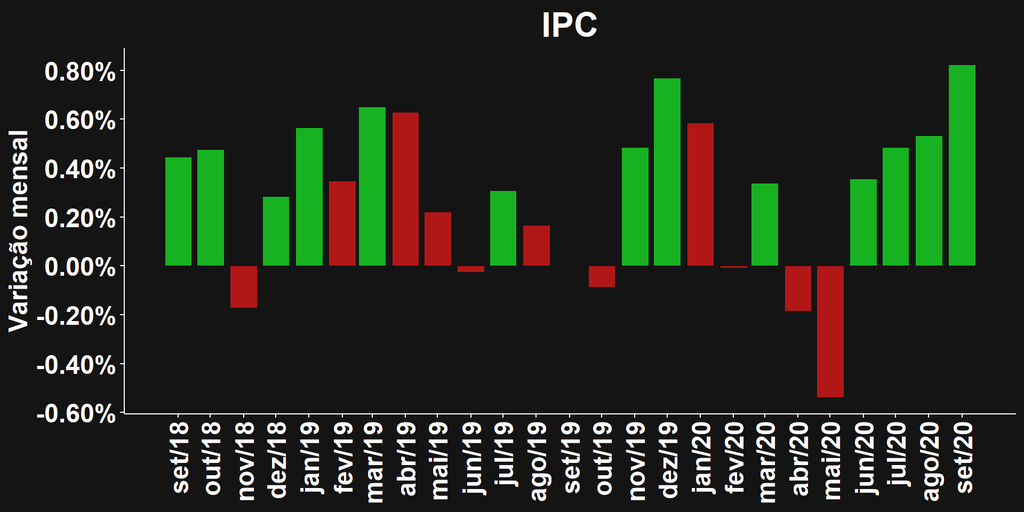

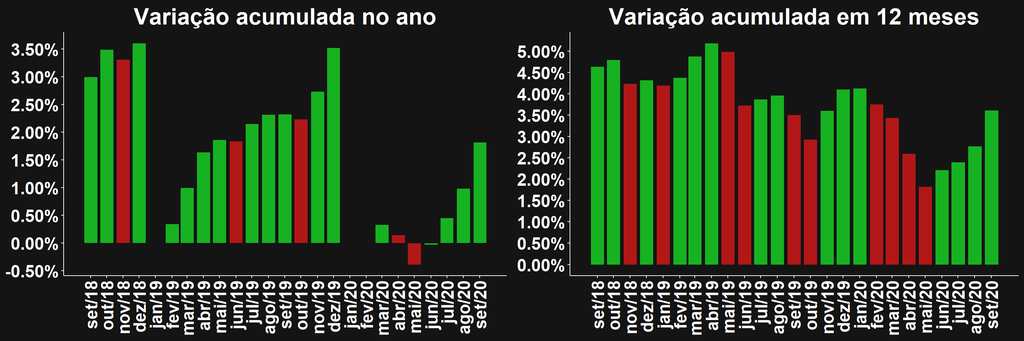

O Indíce Nacional de Custos de Construção (INCC), integrante do IGP-DI com peso de 10%, apresentou variação de 1.16% em setembro, valor superior ao mesmo período do ano anterior quando apresentou uma taxa de 0.46%. Com esse resultado o indíce acumula no ano uma variação positiva de 4.48%, e em 12 meses uma variação positiva de 5.32%.

|  | 09/2019 | 08/2020 | 09/2020 |
| --- | --- | --- | --- |
| Variação mensal | 0.46% | 0.72% | 1.16% |
| Variação acumulada no ano | 3.2% | 3.28% | 4.48% |
| Variação acumulada em 12 meses | 4.35% | 4.6% | 5.32% |

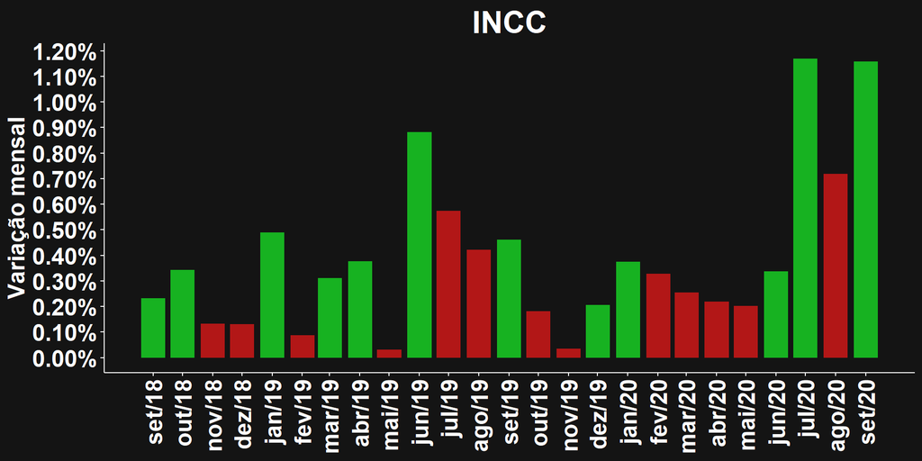

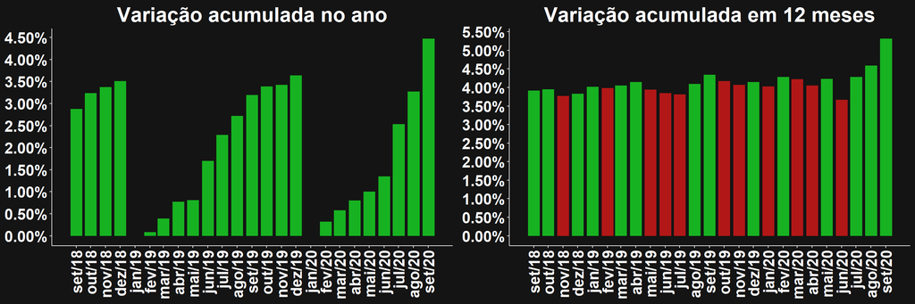

# Estatísticas

As estatísticas descritivas a seguir são feitas com base nos últimos 48 meses, e tem como objetivo possibilitar a avaliação do resultado observado em comparação aos períodos anteriores.

|  | Minimo | 1 Quartil | Mediana | Media | 3 Quartil | Maximo | Desvio Padrão |
| --- | --- | --- | --- | --- | --- | --- | --- |
| IPCA | -0.38% | 0.14% | 0.26% | 0.27% | 0.38% | 1.26% | 0.3% |
| INPC | -0.3% | 0.08% | 0.18% | 0.26% | 0.36% | 1.43% | 0.33% |
| IGP-M | -1.1% | 0.06% | 0.52% | 0.59% | 0.89% | 4.34% | 0.99% |
| IGP-DI | -1.24% | 0.06% | 0.53% | 0.6% | 0.96% | 3.87% | 0.99% |
| IPA | -1.96% | -0.05% | 0.63% | 0.74% | 1.28% | 5.44% | 1.44% |
| IPC | -0.54% | 0.16% | 0.33% | 0.31% | 0.49% | 1.19% | 0.31% |
| INCC | -0.02% | 0.18% | 0.31% | 0.37% | 0.43% | 1.17% | 0.28% |

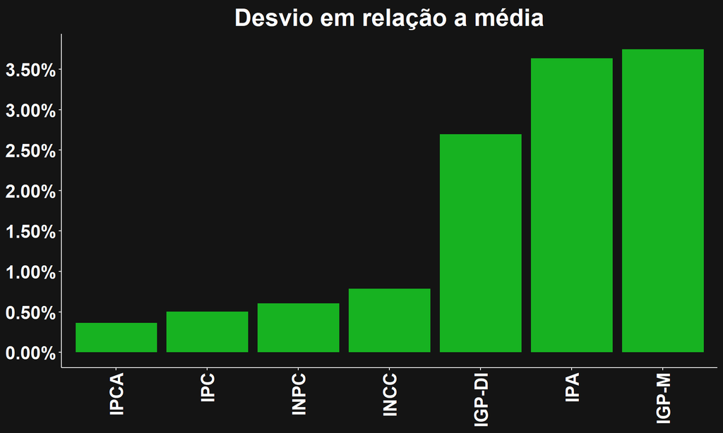

**João Victor Gomes**  
**jvg.santana@gmail.com**  
**[linkedin.com/in/jvictorgomes](https://www.linkedin.com/in/jvictorgomes/)**